# Project 2: Data Mining, Classification, Prediction

SDS322E

# Mining, Classification, Prediction

## Neusha Saboorian, ncs866

### Introduction

This dataset comes from the “Data Is Plural” collective and consists of what were originally four different datasets reporting nutrition value for select foods by the Government of Canada in the Canada Nutrient File database. The new tidied and joined data set named “food” consists of the foods studied, the types of nutrients estimated for every food, the nutrient value for each, and their corresponding units of measure among other variables. After joining to construct my new dataset, “food” consisted of 4,288 distinct foods and drinks and measured 151 different nutrients. I selected this data because I have always been focused on improving my own nutrition, and since the U.S. does not have a great reputation for healthy eating, Canada was the next best option in terms of foods available and widely consumed in North America. I predict that this dataset will allow me to relate many foods to their strength in specific nutrients (some may be surprising) which is knowledge I can apply to my own dietary choices.

```r
library(tidyverse)

food_name <- read_csv("/stor/home/ncs866/project2/FOOD NAME.csv")
nutrient_amount <- read_csv("/stor/home/ncs866/project2/NUTRIENT AMOUNT.csv")
nutrient_name <- read_csv("/stor/home/ncs866/project2/NUTRIENT NAME.csv")
nutrient_source <- read_csv("/stor/home/ncs866/project2/NUTRIENT SOURCE.csv")

first_join <- inner_join(nutrient_source, nutrient_amount, by = "NutrientSourceID")
first_join
```

```
## # A tibble: 524,674 x 10
##    NutrientSourceID NutrientSourceC… NutrientSourceD… `NutrientSourc … FoodID
##               <dbl>            <dbl> <chr>            <chr>             <dbl>
##  1                0                0 No change from … "Provient int\x…      5
##  2                0                0 No change from … "Provient int\x…      5
##  3                0                0 No change from … "Provient int\x…      5
##  4                0                0 No change from … "Provient int\x…      5
##  5                0                0 No change from … "Provient int\x…      5
##  6                0                0 No change from … "Provient int\x…      5
##  7                0                0 No change from … "Provient int\x…      5
##  8                0                0 No change from … "Provient int\x…      5
##  9                0                0 No change from … "Provient int\x…      5
## 10                0                0 No change from … "Provient int\x…      5
## # … with 524,664 more rows, and 5 more variables: NutrientID <dbl>,
## #   NutrientValue <dbl>, StandardError <dbl>, NumberofObservations <dbl>,
## #   NutrientDateOfEntry <date>
```

```r
food1 <- inner_join(first_join, nutrient_name, by = "NutrientID")
food1
```

```
## # A tibble: 524,673 x 17
##    NutrientSourceID NutrientSourceC… NutrientSourceD… `NutrientSourc … FoodID
##               <dbl>            <dbl> <chr>            <chr>             <dbl>
##  1                0                0 No change from … "Provient int\x…      5
##  2                0                0 No change from … "Provient int\x…      5
##  3                0                0 No change from … "Provient int\x…      5
##  4                0                0 No change from … "Provient int\x…      5
##  5                0                0 No change from … "Provient int\x…      5
##  6                0                0 No change from … "Provient int\x…      5
##  7                0                0 No change from … "Provient int\x…      5
##  8                0                0 No change from … "Provient int\x…      5
##  9                0                0 No change from … "Provient int\x…      5
## 10                0                0 No change from … "Provient int\x…      5
## # … with 524,663 more rows, and 12 more variables: NutrientID <dbl>,
## #   NutrientValue <dbl>, StandardError <dbl>, NumberofObservations <dbl>,
## #   NutrientDateOfEntry <date>, NutrientCode <dbl>, NutrientSymbol <chr>,
## #   NutrientUnit <chr>, NutrientName <chr>, NutrientNameF <chr>, Tagname <chr>,
## #   NutrientDecimals <dbl>
```

```r
food <- left_join(food_name, food1, by = "FoodID")
food
```

```
## # A tibble: 524,673 x 21
##    FoodID FoodCode FoodGroupID FoodSourceID FoodDescription NutrientSourceID
##     <dbl>    <dbl>       <dbl>        <dbl> <chr>                      <dbl>
##  1      2        2          22           20 Cheese souffle                 2
##  2      2        2          22           20 Cheese souffle                 4
##  3      2        2          22           20 Cheese souffle                 4
##  4      2        2          22           20 Cheese souffle                 4
##  5      2        2          22           20 Cheese souffle                12
##  6      2        2          22           20 Cheese souffle                12
##  7      2        2          22           20 Cheese souffle                12
##  8      2        2          22           20 Cheese souffle                12
##  9      2        2          22           20 Cheese souffle                12
## 10      2        2          22           20 Cheese souffle                12
## # … with 524,663 more rows, and 15 more variables: NutrientSourceCode <dbl>,
## #   NutrientSourceDescription <chr>, `NutrientSourc DescriptionF` <chr>,
## #   NutrientID <dbl>, NutrientValue <dbl>, StandardError <dbl>,
## #   NumberofObservations <dbl>, NutrientDateOfEntry <date>, NutrientCode <dbl>,
## #   NutrientSymbol <chr>, NutrientUnit <chr>, NutrientName <chr>,
## #   NutrientNameF <chr>, Tagname <chr>, NutrientDecimals <dbl>
```

```r
food <- food %>% select(-2, -3, -4, -6, -7, -9, -14, -16, -17,
    -19, -20, -21)
food <- food %>% select(1, 2, 5, 9, everything())
food <- na.omit(food)
food
```

```
## # A tibble: 88,921 x 9
##    FoodID FoodDescription NutrientValue NutrientName NutrientSourceD… NutrientID
##     <dbl> <chr>                   <dbl> <chr>        <chr>                 <dbl>
##  1      2 Cheese souffle         853    ENERGY (KIL… Nutrient calcul…        268
##  2      2 Cheese souffle           2.55 TOTAL NIACI… Nutrient calcul…        409
##  3      2 Cheese souffle           9.54 PROTEIN      Calculated usin…        203
##  4      2 Cheese souffle          15.7  FAT (TOTAL … Calculated usin…        204
##  5      2 Cheese souffle           5.91 CARBOHYDRAT… Calculated usin…        205
##  6      2 Cheese souffle           1.67 ASH, TOTAL   Calculated usin…        207
##  7      2 Cheese souffle         204    ENERGY (KIL… Calculated usin…        208
##  8      2 Cheese souffle          67.2  MOISTURE     Calculated usin…        255
##  9      2 Cheese souffle           0.1  FIBRE, TOTA… Calculated usin…        291
## 10      2 Cheese souffle         184    CALCIUM      Calculated usin…        301
## # … with 88,911 more rows, and 3 more variables: StandardError <dbl>,
## #   NumberofObservations <dbl>, NutrientCode <dbl>
```

```r
food %>% count(FoodDescription)
```

```
## # A tibble: 4,288 x 2
##    FoodDescription                                               n
##    <chr>                                                     <int>
##  1 Acerola (West Indian cherry), raw                             3
##  2 Acerola juice, raw                                            1
##  3 Alcohol, beer, light (4% alcohol by volume)                  25
##  4 Alcohol, beer, regular, (5% alcohol by volume)               36
##  5 Alcohol, cocktail, daiquiri (rum), homemade                   2
##  6 Alcohol, cocktail, pina colada (rum), homemade                2
##  7 Alcohol, cocktail, scotch and soda                           66
##  8 Alcohol, cocktail, whisky sour mix, bottled                   3
##  9 Alcohol, cocktail, whisky sour mix, bottled, whisky added     4
## 10 Alcohol, cocktail, whisky sour mix, powder                    1
## # … with 4,278 more rows
```

```r
food %>% count(n_distinct(NutrientName))
```

```
## # A tibble: 1 x 2
##   `n_distinct(NutrientName)`     n
##                        <int> <int>
## 1                        151 88921
```

### Cluster Analysis

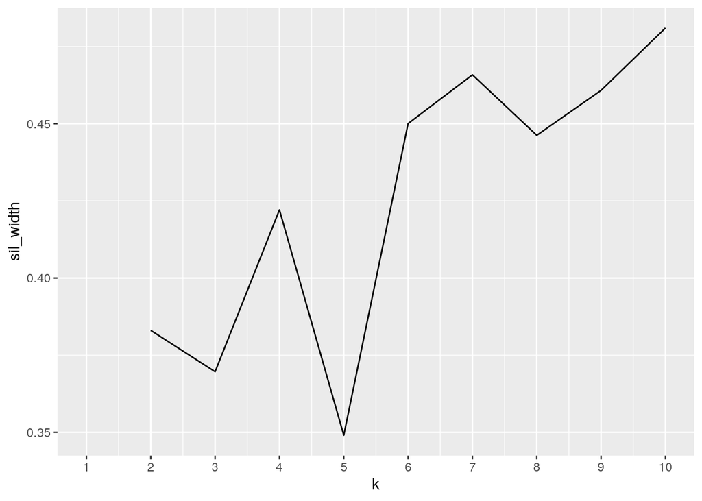

```r
library(cluster)
first_6000 <- food[1:6000, ]
pam_dat <- first_6000 %>% select(is.numeric)
sil_width <- vector()
for (i in 2:10) {
    pam_fit <- pam(pam_dat, k = i)
    sil_width[i] <- pam_fit$silinfo$avg.width
}
ggplot() + geom_line(aes(x = 1:10, y = sil_width)) + scale_x_continuous(name = "k",
    breaks = 1:10)
```

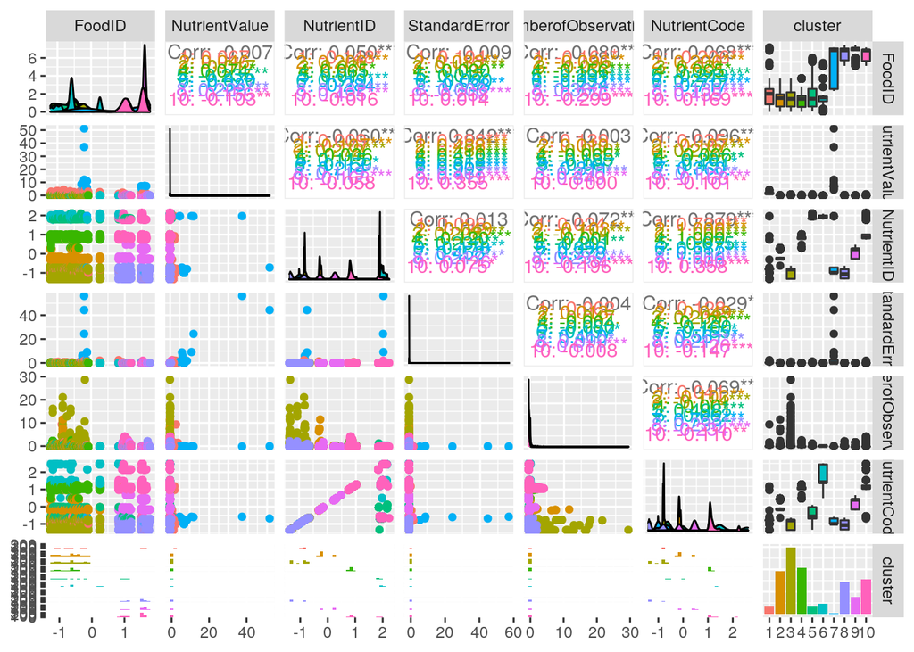

```r
pam1 <- first_6000 %>% pam(k = 10)
final <- first_6000 %>% select(is.numeric) %>% scale %>% as.data.frame
final <- final %>% mutate(cluster = as.factor(pam1$clustering))
library(GGally)
ggpairs(final, columns = 1:7, aes(color = cluster))
```

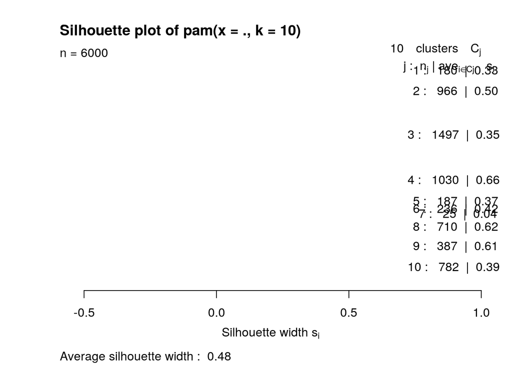

```r
plot(pam1, which = 2)
```

PAM clustering was performed on the first 6000 rows of the food data set in order to maximize efficiency however, the clustering was performed on all of the numeric variables within the data set. Next, a clustering plot was added with ggpairs which allowed us to visualize all pairwise combinations of variables colored by cluster assignment. Based on this plot, the variables NutrientCode and NutrientID had the highest correlation, which is understandable given that the data collectors related the two to the same nutrient when collecting. PAM clustering generated ten clusters with an average silhouette width of only 0.48. This value indicates that prediction via PAM clustering is weak and the structure could be artificial. This could be due to the fact that too many numerical variables were involved in this clustering, especially considering some of them solely served as a label or ID number and do not relate to actual nutrient value of the foods observed.

### Dimensionality Reduction with PCA

```r
food_nums <- food %>% select(where(is.numeric)) %>% scale
rownames(food_nums) <- food$FoodDescription
food_pca <- princomp(food_nums)
names(food_pca)
```

```
## [1] "sdev"     "loadings" "center"   "scale"    "n.obs"    "scores"   "call"
```

```r
summary(food_pca, loadings = T)
```

```
## Importance of components:
##                           Comp.1    Comp.2    Comp.3    Comp.4     Comp.5
## Standard deviation     1.4016057 1.2508867 0.9936695 0.9678184 0.65065958
## Proportion of Variance 0.3274201 0.2607892 0.1645650 0.1561138 0.07056044
## Cumulative Proportion  0.3274201 0.5882093 0.7527744 0.9088882 0.97944862
##                            Comp.6
## Standard deviation     0.35115077
## Proportion of Variance 0.02055138
## Cumulative Proportion  1.00000000
##
## Loadings:
##                      Comp.1 Comp.2 Comp.3 Comp.4 Comp.5 Comp.6
## FoodID                0.241         0.214  0.945
## NutrientValue        -0.141  0.692                0.708
## NutrientID            0.667  0.132        -0.192         0.705
## StandardError        -0.101  0.701               -0.706
## NumberofObservations -0.119         0.974 -0.189
## NutrientCode          0.673               -0.183        -0.708
```

```r
eigen(cor(food_nums))
```

```
## eigen() decomposition
## $values
## [1] 1.9645207 1.5647352 0.9873902 0.9366830 0.4233626 0.1233083
##
## $vectors
##            [,1]        [,2]         [,3]         [,4]          [,5]
## [1,]  0.2411460 -0.04479552 -0.214125550  0.945481245  0.0052887306
## [2,] -0.1406785 -0.69188375 -0.002974739 -0.001367030  0.7075812343
## [3,]  0.6670094 -0.13247466 -0.048838648 -0.191683070  0.0311226323
## [4,] -0.1007824 -0.70105529 -0.006720425 -0.005043419 -0.7058640275
## [5,] -0.1194979  0.02837508 -0.974299739 -0.188824557 -0.0004904814
## [6,]  0.6728445 -0.09724729 -0.049507989 -0.183414280  0.0093777407
##               [,6]
## [1,] -0.0054297824
## [2,]  0.0287143036
## [3,] -0.7053032182
## [4,]  0.0070549549
## [5,]  0.0004218012
## [6,]  0.7082679058
```

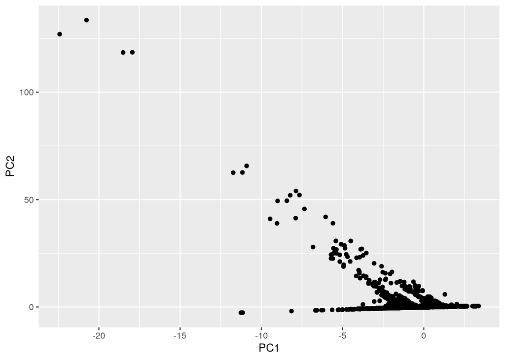

```r
eigval <- food_pca$sdev^2
varprop = round(eigval/sum(eigval), 2)

fooddf <- data.frame(PC1 = food_pca$scores[, 1], PC2 = food_pca$scores[,
    2])


ggplot(fooddf, aes(PC1, PC2)) + geom_point()
```

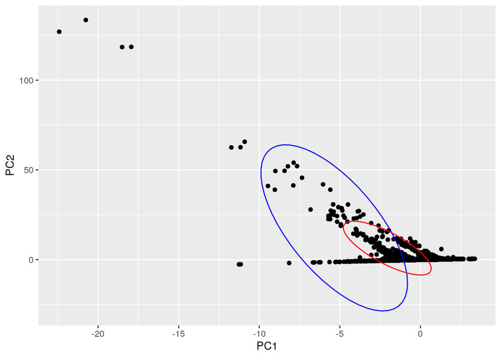

```r
ggplot(fooddf, aes(PC1, PC2)) + geom_point() + stat_ellipse(data = fooddf[fooddf$PC1 >
    5, ], aes(PC1, PC2), color = "blue") + stat_ellipse(data = fooddf[fooddf$PC1 <
    -3.8, ], aes(PC1, PC2), color = "blue") + stat_ellipse(data = fooddf[fooddf$PC2 >
    2.75, ], aes(PC1, PC2), color = "red") + stat_ellipse(data = fooddf[fooddf$PC2 <
    -3.5, ], aes(PC1, PC2), color = "red")
```

### Linear Classifier

```r
food <- food %>% mutate(Source = ifelse(NutrientSourceDescription ==
    "Calculated using a recipe", 1, 0))
head(food)
```

```
## # A tibble: 6 x 10
##   FoodID FoodDescription NutrientValue NutrientName NutrientSourceD… NutrientID
##    <dbl> <chr>                   <dbl> <chr>        <chr>                 <dbl>
## 1      2 Cheese souffle         853    ENERGY (KIL… Nutrient calcul…        268
## 2      2 Cheese souffle           2.55 TOTAL NIACI… Nutrient calcul…        409
## 3      2 Cheese souffle           9.54 PROTEIN      Calculated usin…        203
## 4      2 Cheese souffle          15.7  FAT (TOTAL … Calculated usin…        204
## 5      2 Cheese souffle           5.91 CARBOHYDRAT… Calculated usin…        205
## 6      2 Cheese souffle           1.67 ASH, TOTAL   Calculated usin…        207
## # … with 4 more variables: StandardError <dbl>, NumberofObservations <dbl>,
## #   NutrientCode <dbl>, Source <dbl>
```

```r
fit <- glm(Source ~ NutrientValue + NutrientID + StandardError +
    NumberofObservations + FoodID, data = food, family = "binomial")
prob_reg <- predict(fit, type = "response")
class_diag(prob_reg, food$Source, positive = 1)
```

```
##            acc sens spec ppv  f1  ba    auc
## Metrics 0.9966    0    1 NaN NaN 0.5 0.9464
```

```r
set.seed(1234)
k = 10
data <- food[sample(nrow(food)), ]
folds <- cut(seq(1:nrow(food)), breaks = k, labels = F)
diags <- NULL
for (i in 1:k) {

    train <- data[folds != i, ]
    test <- data[folds == i, ]
    truth <- test$Source

    fit <- glm(Source ~ NutrientValue + NutrientID + StandardError +
        NumberofObservations + FoodID, data = train, family = "binomial")

    probs <- predict(fit, newdata = test, type = "response")

    diags <- rbind(diags, class_diag(probs, truth, positive = 1))
}
summarize_all(diags, mean)
```

```
##       acc sens spec ppv  f1  ba     auc
## 1 0.99659    0    1 NaN NaN 0.5 0.94552
```

### Non-Parametric Classifier

```r
library(caret)
knn_fit <- knn3(Source ~ NutrientValue + NutrientID + StandardError +
    NumberofObservations + FoodID, data = food)
prob_knn <- predict(knn_fit, newdata = food)[, 2]
class_diag(prob_knn, truth = food$Source, positive = 1)
```

```
##            acc  sens   spec    ppv     f1     ba    auc
## Metrics 0.9985 0.637 0.9998 0.9019 0.7466 0.8184 0.9994
```

```r
set.seed(322)
k = 10

data <- sample_frac(food)
folds <- rep(1:k, length.out = nrow(data))

diags <- NULL

i = 1
for (i in 1:k) {

    train <- data[folds != i, ]
    test <- data[folds == i, ]
    truth <- test$Source


    fit <- knn3(Source ~ NutrientValue + NutrientID + StandardError +
        NumberofObservations + FoodID, data = train)


    probs <- predict(fit, newdata = test)[, 2]


    diags <- rbind(diags, class_diag(probs, truth, positive = 1))
}


summarize_all(diags, mean)
```

```
##       acc    sens    spec     ppv      f1      ba    auc
## 1 0.99772 0.50153 0.99941 0.75797 0.59737 0.75049 0.9368
```

After using knn as a non-parametric classifier to predict the source of nutrients, the AUC value came out to 99.9%; the highest yet. This indicates that using a knn fit is the most accurate method for predicting source from all other numeric variables (accuracy = 99.9%). However, the model did show signs of overfitting when preforming a k-fold CV, as the AUC decreased to 0.9368, a noticeable drop from the near 100% value previously.

### Regression/Numeric Prediction

```r
food_reg <- food %>% select(-FoodDescription) %>% select(-NutrientName) %>%
    select(-NutrientSourceDescription)
head(food_reg)
```

```
## # A tibble: 6 x 7
##   FoodID NutrientValue NutrientID StandardError NumberofObserva… NutrientCode
##    <dbl>         <dbl>      <dbl>         <dbl>            <dbl>        <dbl>
## 1      2        853           268             0                0          268
## 2      2          2.55        409             0                0          409
## 3      2          9.54        203             0                0          203
## 4      2         15.7         204             0                0          204
## 5      2          5.91        205             0                0          205
## 6      2          1.67        207             0                0          207
## # … with 1 more variable: Source <dbl>
```

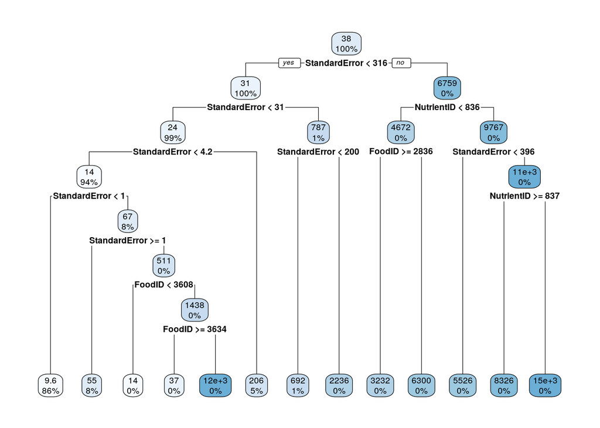

```r
library(rpart)
library(rpart.plot)
fit <- rpart(NutrientValue ~ ., data = food_reg)
rpart.plot(fit)
```

```r
library(caret)
fit <- train(NutrientValue ~ ., data = food_reg, method = "rpart")
fit$bestTune
```

```
##          cp
## 1 0.0429025
```

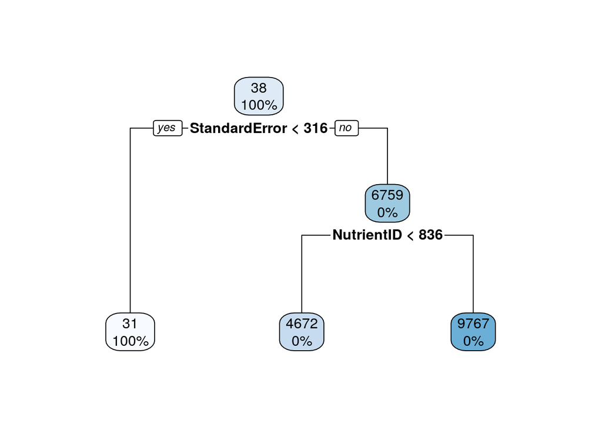

```r
rpart.plot(fit$finalModel)
```

```r
yhat <- predict(fit)
mean((food_reg$NutrientValue - yhat)^2)
```

```
## [1] 77254.46
```

```r
library(rpart)
set.seed(1234)
k = 10
data <- food_reg[sample(nrow(food)), ]
folds <- cut(seq(1:nrow(food_reg)), breaks = k, labels = F)
MSE <- NULL
for (i in 1:k) {

    train <- data[folds != i, ]
    test <- data[folds == i, ]
    truth <- test$NutrientValue

    fit <- rpart(NutrientValue ~ ., data = train)

    pred <- predict(fit, newdata = test)

    MSE <- cbind(MSE, mean((truth - pred)^2))
}
mean(MSE)
```

```
## [1] 77435.77
```

### Python

```r
library(reticulate)
use_python("/usr/bin/python3")
# py_install('matplotlib') py_install('numpy')
# py_install('pandas')

library(dplyr)
food1 <- food %>% select(-2)

food %>% arrange(desc(NutrientValue))
```

```
## # A tibble: 88,921 x 10
##    FoodID FoodDescription NutrientValue NutrientName NutrientSourceD… NutrientID
##     <dbl> <chr>                   <dbl> <chr>        <chr>                 <dbl>
##  1   2258 Tomato product…         28764 LYCOPENE     No change from …        836
##  2 501801 Tomato product…         28764 LYCOPENE     No change from …        836
##  3    196 Spices, paprika         26162 BETA CAROTE… No change from …        321
##  4   2259 Tomato product…         21754 LYCOPENE     No change from …        836
##  5 501802 Tomato product…         21754 LYCOPENE     No change from …        836
##  6   3618 Veal, liver, b…         21145 RETINOL ACT… No change from …        814
##  7   3618 Veal, liver, b…         21140 RETINOL      No change from …        319
##  8   3619 Veal, liver, p…         20070 RETINOL      No change from …        319
##  9    196 Spices, paprika         18944 LUTEIN AND … No change from …        837
## 10   2105 Kale, boiled, …         18246 LUTEIN AND … No change from …        837
## # … with 88,911 more rows, and 4 more variables: StandardError <dbl>,
## #   NumberofObservations <dbl>, NutrientCode <dbl>, Source <dbl>
```

```r
food %>% arrange(desc(NutrientValue)) %>% arrange(StandardError)
```

```
## # A tibble: 88,921 x 10
##    FoodID FoodDescription NutrientValue NutrientName NutrientSourceD… NutrientID
##     <dbl> <chr>                   <dbl> <chr>        <chr>                 <dbl>
##  1   4085 Shake and bake…          4030 SODIUM       Nutrient value …        307
##  2   2962 Lemonade with …          3722 ASPARTAME    Nutrient from t…        550
##  3    523 Shortening, in…          3697 ENERGY (KIL… Nutrient impute…        268
##  4    535 Animal fat, na…          3697 ENERGY (KIL… Nutrient derive…        268
##  5    539 Shortening, ho…          3697 ENERGY (KIL… Nutrient impute…        268
##  6    540 Shortening, in…          3697 ENERGY (KIL… Nutrient impute…        268
##  7    541 Shortening, in…          3697 ENERGY (KIL… Nutrient impute…        268
##  8    542 Shortening, in…          3697 ENERGY (KIL… Nutrient impute…        268
##  9    543 Shortening, in…          3697 ENERGY (KIL… Nutrient impute…        268
## 10    544 Shortening, in…          3697 ENERGY (KIL… Nutrient impute…        268
## # … with 88,911 more rows, and 4 more variables: StandardError <dbl>,
## #   NumberofObservations <dbl>, NutrientCode <dbl>, Source <dbl>
```

```r
food %>% filter(FoodID == 503355) %>% filter(NutrientValue ==
    0)
```

```
## # A tibble: 31 x 10
##    FoodID FoodDescription NutrientValue NutrientName NutrientSourceD… NutrientID
##     <dbl> <chr>                   <dbl> <chr>        <chr>                 <dbl>
##  1 503355 Babyfood, cere…             0 GALACTOSE    Nutrient analyz…        287
##  2 503355 Babyfood, cere…             0 FATTY ACIDS… Nutrient analyz…        608
##  3 503355 Babyfood, cere…             0 FATTY ACIDS… Nutrient analyz…        621
##  4 503355 Babyfood, cere…             0 FATTY ACIDS… Nutrient analyz…        625
##  5 503355 Babyfood, cere…             0 FATTY ACIDS… Nutrient analyz…        627
##  6 503355 Babyfood, cere…             0 FATTY ACIDS… Nutrient analyz…        629
##  7 503355 Babyfood, cere…             0 FATTY ACIDS… Nutrient analyz…        631
##  8 503355 Babyfood, cere…             0 FATTY ACIDS… Nutrient analyz…        652
##  9 503355 Babyfood, cere…             0 FATTY ACIDS… Nutrient analyz…        653
## 10 503355 Babyfood, cere…             0 FATTY ACIDS… Nutrient analyz…        654
## # … with 21 more rows, and 4 more variables: StandardError <dbl>,
## #   NumberofObservations <dbl>, NutrientCode <dbl>, Source <dbl>
```

```python
import pandas as pd
r.food1["NutrientValue"].max()
```

```
## 28764.0
```

```python
r.food1["NutrientValue"].median()
```

```
## 0.442
```

```python
r.food1["NutrientValue"].min()
```

```
## 0.0
```

```python
(r.food1.filter(['NutrientValue','FoodID'])
 .sort_values('NutrientValue').head(3))
```

```
##        NutrientValue    FoodID
## 88920            0.0  503355.0
## 73586            0.0  502030.0
## 73588            0.0  502030.0
```

In the R chunk above, basic wrangling was done to manipulate the food dataset into a separate dataset named “food1” to make it able to run through python. In addition, the original food dataset was wrangled to provide some insight into its properties, namely I was able to find that canned tomato paste had the highest individual nutrient value, in terms of the nutrient lycopene a powerful antioxidant and carotenoid. Meanwhile, when taking into account standard error, the food with the highest nutrient value becomes the spice mix ‘shake and bake’ with a sodium nutrient value of 4030 and a standard error of 0. This shows that although foods can be high in nutrient value, it does not necessarily mean it is the healthiest nutrient, or by those same standards, the healthiest food. In the python chunk below, reticulate was used to call the food1 dataset in R to report the minimum, median, and maximum values of nutrient value in the dataset. Additionally, a chain of commands was applied to food1 in order to note that the food with the lowest nutrient value is ID number 503355. This food was determined to be babyfood cereal with powdered milk and fruits which has no value in the monosaccharide galactose and many fatty acids. The absence of galactose is noted in the diets of infants that are born with innate errors in metabolizing this sugar, which can cause a condition called ‘galactosemia.’

### Concluding Remarks

Overall, the modeling of this dataset bore less information than desired when predicting nutrient value in a wide range of foods. Potential issues may have arisen with the size of the dataset, where thousands of food items were recorded, perhaps sampling a fraction of these foods and modeling from there would provide better fitting predictions in the future.